# Práctica I

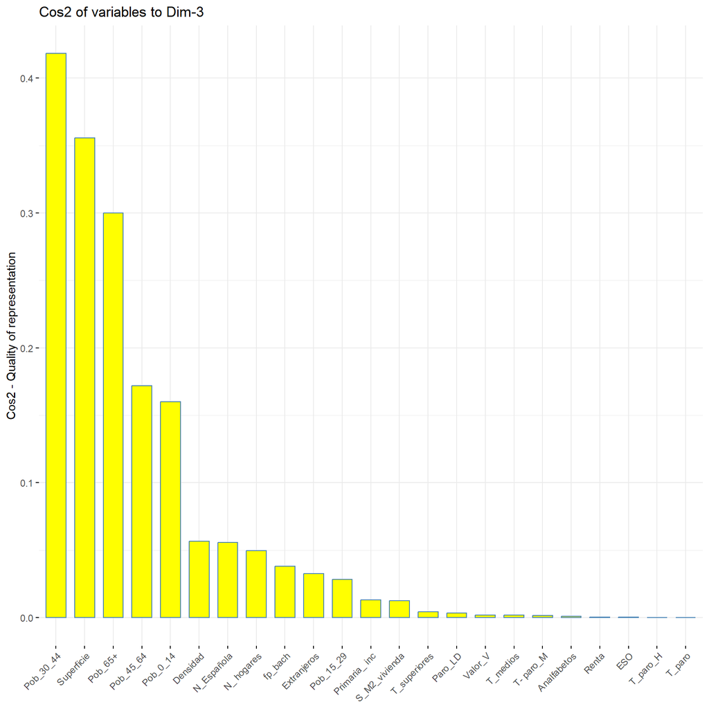

```r
fviz_cos2(pca_fit,
          choice = "var",
          axes = 3,
          fill = "yellow")
```

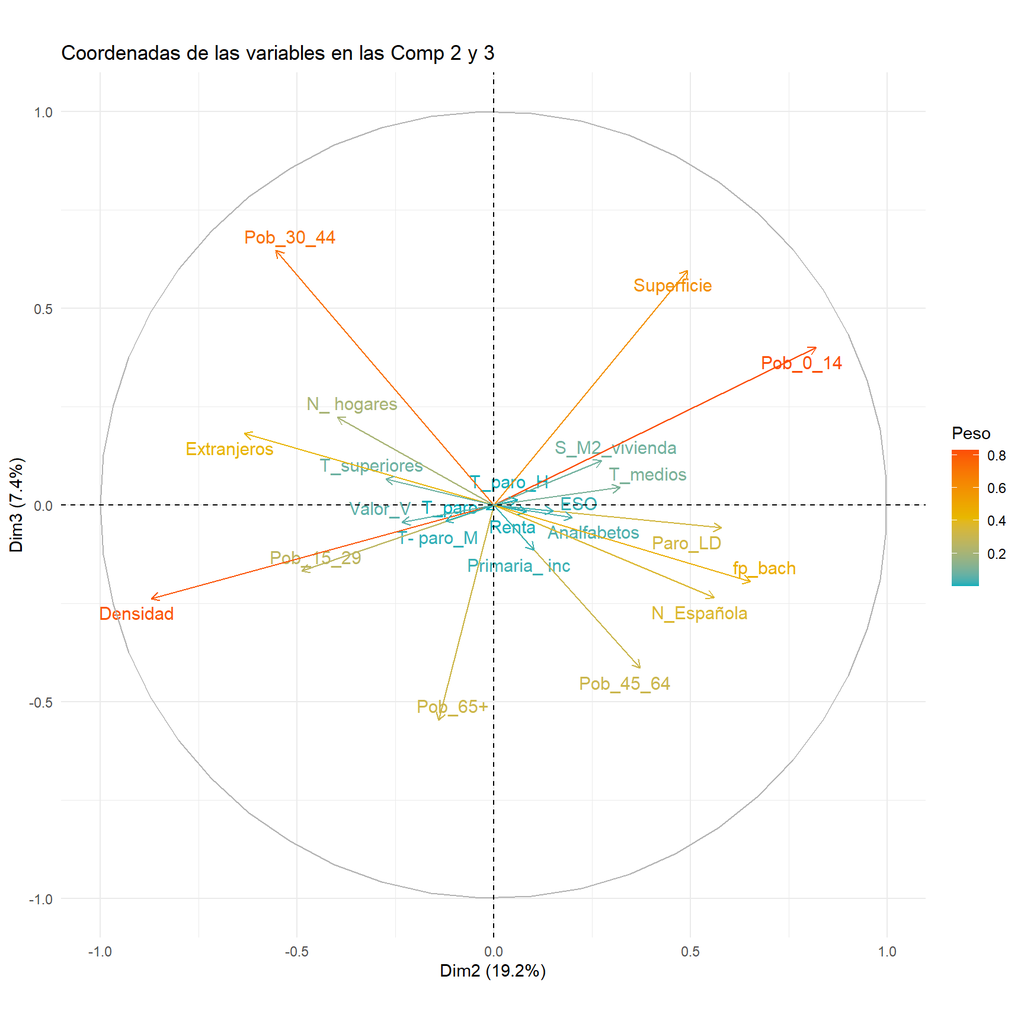

```r
# observando estos 3 gráficos + el gráfico fviz_pca_var del EJERCICIO 7.1, deducimos que:

# - DIM.1 representa principalmente la información socioeconómica asociada a las
# tasas de paro, a los niveles de estudio, a la renta, y al valor de la vivienda.

# - Dim.2 representa principalmente la información asociada a la densidad de población,
# y al porcentaje de menores de 14 años.

# - Dim.3 tiene valores de cos2 bajos, por lo que no representa demasiado bien
# ninguna variab orig. No obstante, con la siguiente representación vemos que la
# combinación de las componentes 2 y 3 nos explica principalmente la información
# relativa a la población: tanto los % de población como la densidad (y lógicamente,
# si tienes población y densidad, tienes superficie, que vemos que también está
# relativamente bien representada por estas dos componentes):

fviz_pca_var(pca_fit, col.var = "cos2",
             gradient.cols = col,
             axes = c(2,3), # con axes elegimos las Dims que queremos ver
             repel = TRUE) +
  theme_minimal() +
  labs(color= "Peso") +
  ggtitle("Coordenadas de las variables en las Comp 2 y 3")
```

## Ejercicio 7.4

> Haz uso de `fviz_pca_biplot()` para visualizar los dos gráficos anteriores de forma conjunta y personaliza todo lo que consideres del gráfico. Detalla lo que consideres del gráfico y analiza los grupos de distritos creados en función del partido más votado (le indicamos que el color dependa de dicha variable en `col.ind`)

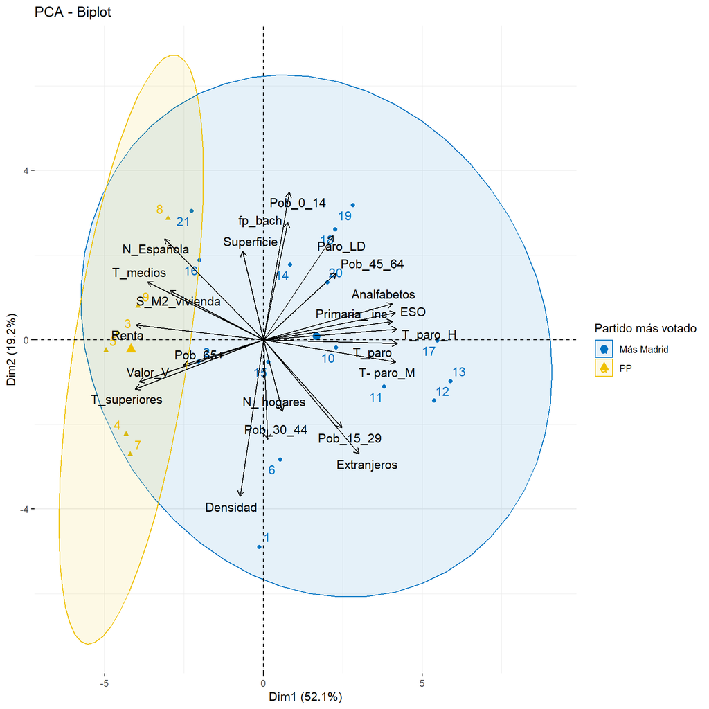

```r
fviz_pca_biplot(pca_fit,
                col.ind = distritos$Partido,
                palette = "jco",
                addEllipses = TRUE,
                label = c("var","ind"),
                col.var = "black",
                repel = TRUE,
                legend.title = "Partido más votado")
```

```r
# comentar las características socioeconómicas de algunos grupos de distritos:
# RESPUESTA:
# Se observa que los distritos donde gana el PP tienden a ser los de mayor Renta,
# N_Española, Pob_65+, T_superiores, Valor_V y S_M2_vivienda.

# Por otra parte, podemos distinguir algunos subgrupos de distritos en los que
# gana Más Madrid que tienen características similares:
# - a la derecha del gráfico, el subgrupo de distritos con altas tasas de paro,
#   y elevados índices de personas con estudios de nivel bajo (ESO, Primaria_ inc).
# - En el primer cuadrante del gráfico, también vemos otro subgrupo de distritos
#   con alta tasa de paro de larga duración, población adulta evejecida (45 a 64),
#   niveles de estudios algo superiores, sobretodo entre Primaria, ESO y fp_bach.
```

# Ejercicio 8

> ¿Qué valor tiene el distrito de Salamanca en la Componente 1? ¿Y Villaverde? ¿Qué distrito tiene un valor más alto de la Componente 4? Ejecuta el código que consideres

```r
# pca_fit$ind$coord # scores

pca_fit$ind$coord[which(distritos$Distrito == "SALAMANCA"), 1]
```

```
[1] -4.326101
```

```r
# Salamanca tiene Dim1 = -4.326
pca_fit$ind$coord[which(distritos$Distrito == "VILLAVERDE"), 1]
```

```
[1] 5.482688
```

```r
# Villaverde tiene Dim1 = 5.483

distritos$Distrito[which.max(pca_fit$ind$coord[ ,"Dim.4"])]
```

```
[1] "FUENCARRAL-EL PARDO"
```

```r
# El distrito con valor más alto de la comp 4 es FUENCARRAL-EL PARDO
```

# Ejercicio 9

> Comenta/concluye todo lo que consideres tras un análisis numérico y visual, y que no haya sido preguntado.

# Ejercicio 10 (extra)

> Haz uso de tidymodels para calcular las componentes y las 5 componentes que más varianza capturan en una matriz de gráficas (la diagonal la propia densidad de las componentes, fuera de la diagonal los datos proyectados en la componente (i,j)). Codifica el color como el partido más votado. Al margen de la varianza explicada, ¿qué par de componentes podrían servirnos mejor para «clasificar» nuestros barrios según el partido más votado (variables que segmenten mejor mi espacio)?

```r
receta <-
  recipe(Partido ~ ., data = distritos[ ,-1]) %>%
  # Species es la varOBj # no metemos el Distrito pq es la variab identificativa
  # Imputamos por la media las numéricas, por la moda las cuali
  step_impute_mean(all_numeric_predictors()) %>%
  step_impute_mode(all_nominal_predictors()) %>%
  # Estandarizamos
  step_normalize(all_numeric_predictors())
receta
```

```
Recipe

Inputs:

      role #variables
   outcome          1
 predictor         23

Operations:

Mean imputation for all_numeric_predictors()
Mode imputation for all_nominal_predictors()
Centering and scaling for all_numeric_predictors()
```

```r
# b) Añadir el pca análisis:
receta <-
  receta %>%
  step_pca(all_numeric_predictors(), num_comp = 5, # (*)
           prefix = "PC")

# (*) recuerda que no podemos poner 23 por las variabs orig linealmente dependientes

# c) aplicar:
data_pc <- bake(receta %>% prep(), new_data = NULL)
data_pc
```

```
# A tibble: 21 × 6
   Partido       PC1    PC2     PC3    PC4    PC5
   <fct>       <dbl>  <dbl>   <dbl>  <dbl>  <dbl>
 1 Más Madrid  0.128  4.78   1.76   -2.12  -0.176
 2 Más Madrid  1.99   0.503 -0.371  -0.993 -1.67
 3 PP          4.48  -0.161 -1.36    0.104 -0.751
 4 PP          4.22   2.18  -0.516   0.154  0.790
 5 PP          4.85   0.242 -0.191   0.325  0.532
 6 Más Madrid -0.520  2.76   0.588  -0.414 -0.330
 7 PP          4.09   2.64  -0.306   0.474  0.359
 8 PP          2.93  -2.80   3.02    2.85  -0.455
 9 PP          3.86  -0.777 -0.0504  0.501  3.14
10 Más Madrid -2.23   0.181 -0.676   1.65  -1.69
# … with 11 more rows
```

```r
names(data_pc)
```

```
[1] "Partido" "PC1"     "PC2"     "PC3"     "PC4"     "PC5"
```

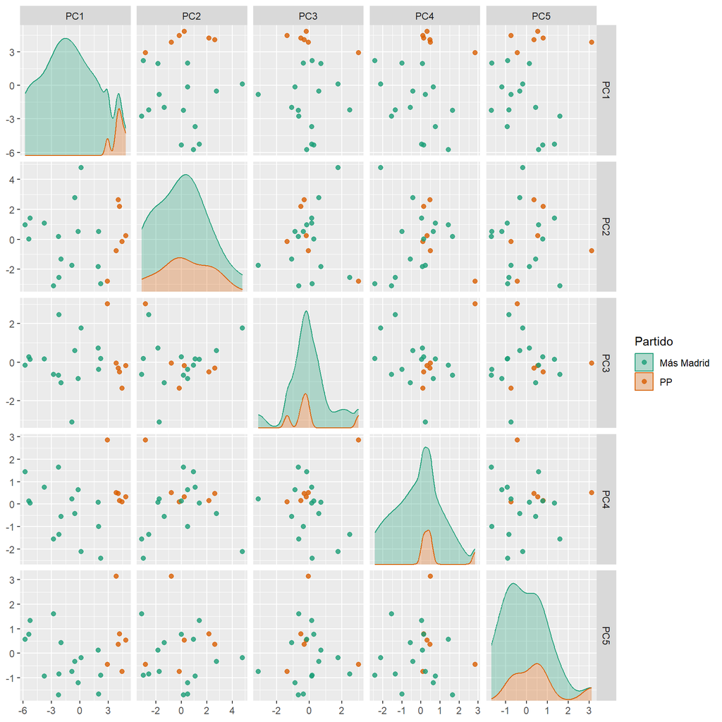

```r
ggplot(data_pc) +
    ggforce::facet_matrix(vars(PC1,PC2,PC3,PC4,PC5),
                        layer.diag = 2) + # opciones gráficas --> 2, TRUE, FALSE, NULL

  geom_point(aes(x = .panel_x, y = .panel_y,
                 color = Partido, fill = Partido),
             alpha = 0.8, size = 1.8) +

  ggforce::geom_autodensity(aes(x = .panel_x, y = .panel_y,
                 color = Partido, fill = Partido),
                            alpha = 0.3) + # alpha - transparencia del relleno de la curva

  scale_color_brewer(palette = "Dark2") +
  scale_fill_brewer(palette = "Dark2")
```

```r
# ¿Qué par de componentes podrían servirnos mejor para «clasificar» nuestros
# barrios según el partido más votado?
# RESPUESTA:
# Visualizando el gráfico, vemos que cualquier combinación de PC1 con PC2, PC3,
# PC4 o PC5 (la fila de arriba del gráfico -o la columna de la izquierda-) nos sirve
# para clasificar adecuadamente, ya que las observaciones de uno y otro partido
# quedan claramente separadas en dos "clusters" que no se entremezclan.
```